# 20221026_ptolemy-api

```python
import os
import numpy as np
import matplotlib.pyplot as plt
import requests
import json
from Smartscope.lib.montage import Montage
%matplotlib inline
```

### Building some REST API fetching logic

To fully separate the worker and the master, the worker will query the REST api for objects. This is to test and feel how it works

```python
API = 'http://lxd-02012614:58000/api/'
TOKEN = '08d03f318d6cb3985eecc84e1ec2b0db272023a2'
auth_headers={'Authorization':f'Token {TOKEN}'}
```

```python
from abc import ABC
from datetime import datetime
from pathlib import Path
from typing import List, Union, Dict
from pydantic import BaseModel, Field

class Finder(BaseModel):
    x: int
    y: int
    stage_x: float
    stage_y: float
    stage_z: float
    method_name: str

class Target(BaseModel, ABC):
    name: str
    number: int
    grid_id: str
    pixel_size: Union[float,None] = None
    shape_x: Union[float,None] = None
    shape_y : Union[float,None] = None
    selected:  bool = False
    status: Union[str,None] = None
    completion_time: Union[datetime,None] = None

    finders: List[Finder]
    ## NEED TO ADD CLASSIFIERS AND SELECTORS BUT IT'S GOOD FOR TESTING RIGHT NOW
    class Config:
        allow_population_by_field_name = True

    @property
    def stage_coords(self) -> np.ndarray:
        return np.array([self.finders[0].stage_x, self.finders[0].stage_y])

class HoleModel(Target):
    hole_id : str = Field(alias='id')
    bis_type: str
    radius: int
    area: float
    square_id: str

class HighMagModel(Target):
    hm_id: Union[str,bool] = Field(alias='id',default=False)
    hole_id:str
    is_x: Union[float,None]= None
    is_y: Union[float,None]= None
    offset: float = 0
    frames: Union[str,None] = None
    defocus: Union[float,None]= None
    astig: Union[float,None]= None
    angast: Union[float,None]= None
    ctffit: Union[float,None]= None
```

Basic API function to build the API endpoint with filters and parse the results with the specified pydantic object class

```python
def get_from_API(route:str,filters:Dict,outputModel:BaseModel) -> List[BaseModel]:
    request_hole = f'{API}{route}/?'
    for i,j in filters.items():
        request_hole += f'{i}={j}&'
    resp = requests.get(request_hole,headers=auth_headers)
    resp_dict = json.loads(resp.content)['results']
    parsed = []
    for item in resp_dict:
        parsed.append(outputModel.parse_obj(item))
    return parsed
```

### Grab the objects from the REST API.

Here we grab a group of hole, identify the center and get the stage coordinates from every hole

```python
parsed = get_from_API(route = 'holes/detailed', filters=dict(bis_group='20_46',grid_id='11test_gridxOD64k7vp6PMYAAUaSQ',page_size=100),outputModel=HoleModel)
center = next(filter(lambda x: x if x.bis_type == 'center' else None, parsed))
stage_coords = np.array([x.stage_coords - center.stage_coords for x in parsed])
```

Load the medium mag montage for that center hole.

*I will need to add the logic of fetching the directory but for now I wrote it down manually*

```python
mont = Montage(center.name, '/datastaging/data/smartscope/testing/20221017_test_sq_center/11_test_grid')
mont.load_or_process()
```

```
2022-10-26 14:07:18 [Smartscope.lib.montage:283 -     INFO]   Found metadata, reading...
```

Map the stage coordinates identified at low mag back on the medium mag image.

We convert distances to pixel and then rotate the points using the rotation angle of the tilt axis

```python
def rotate_axis(coord, angle):
    theta = np.radians(angle)
    c, s = np.cos(theta), np.sin(theta)
    R = np.array(((c, -s), (s, c)))
    rotated = np.sum(R * np.reshape(coord, (-1, 1)), axis=0)
    return rotated
```

```python
rotation = mont.metadata.iloc[0].RotationAngle
pixel_converted = np.array(stage_coords) / (mont.pixel_size/10_000)
pixel=np.apply_along_axis(rotate_axis, 1, pixel_converted, angle=rotation)
```

### Use Ptolemy to find the holes in the medium mag image

There are a few general functions in ptolemy that could also be very useful in SmartScope and may use throughout the code in the future

```python
import sys
sys.path.insert(0, '/home/bouvettej2/Smartscope-dev/ptolemy/')
from ptolemy.images import Exposure
import ptolemy.algorithms as algorithms
import ptolemy.models as models
import torch

def ptolemy_find_holes(montage, model_path='weights/211026_unet_9x64_ep6.torchmodel', cuda=True) -> Exposure:
    ex = Exposure(montage.downsample(scale=4), scale=4)

    segmenter = algorithms.UNet_Segmenter(64, 9, model_path=model_path, dim_mult_of=1024, cuda=cuda)
    ex.make_mask(segmenter)
    processor = algorithms.MedMag_Process_Mask(edge_tolerance=100)
    ex.process_mask(processor)
    cropper = algorithms.MedMag_Process_Crops()
    ex.get_crops(cropper)
    return ex


def pltolemy_classify_holes(exposure: Exposure) -> Exposure:
    model = models.AveragePoolModel(4, 128)
    model.load_state_dict(torch.load('weights/211214_medmag_128x4_avgpool_e5.torchmodel'))
    wrapper = models.Wrapper(model)
    exposure.score_crops(wrapper, final=False)
    return exposure
```

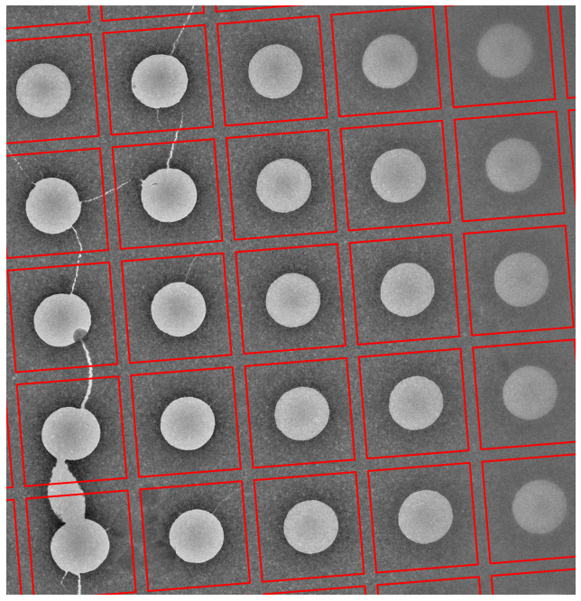

```python
exposure = ptolemy_find_holes(mont, model_path='/home/bouvettej2/Smartscope-dev/ptolemy/weights/211026_unet_9x64_ep6.torchmodel')
exposure.viz_boxes()
```

### Register Ptolemy results to the existing holes and create high mag targets for acquisition

Goal here is to find the parent hole corresponding to the ptolemy result to save the high mag tagets to the database

```python
from scipy.spatial.distance import cdist
```

Convert ouputs to the same format

```python
smartscope_image_coords = pixel + (np.array([mont.shape_x,mont.shape_y])//2)
ptolemy_image_coords = np.array([exposure.crops.center_coords.y*exposure.scale,exposure.crops.center_coords.x*exposure.scale]).transpose()
```

Calculate the distance matrix between the two sets and find closest point

```python
distance_matrix = cdist(smartscope_image_coords,ptolemy_image_coords)
closest_index = np.argmin(distance_matrix,1)

ptolemy_smartscope_register = []
for i,j in zip(smartscope_image_coords,closest_index):
    ptolemy_smartscope_register.append(ptolemy_image_coords[j])
```

### Plot the results

We can see that the points identified by ptolemy are more precise. This is because ptolemy is using a lattice refinement after locating some of or all the holes to ensure even spacing and cover the hole that may have been missed by the Unet.

The register of the holes found in LM is close enough to use a cdist matrix to register them back to their new coordinates.

In the plot, orange is Ptolemy and Blue is Smatscope. We can see why we have targeting issues at high image shifts.

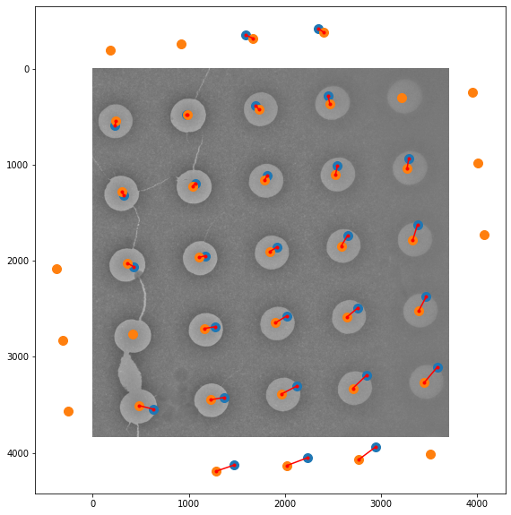

```python
fig= plt.figure(figsize=(10,10))
ax = fig.add_subplot(111)
ax.imshow(mont.image, cmap='gray')
ax.scatter(smartscope_image_coords[:,0],smartscope_image_coords[:,1],marker='o',s=100)
ax.scatter(ptolemy_image_coords[:,0],ptolemy_image_coords[:,1],s=100)
for i,j in zip(smartscope_image_coords,ptolemy_smartscope_register):
    ax.plot([i[0],j[0]],[i[1],j[1]], c='red',marker='.')
```

### Create High Mag objects for the holes

That is to post the results to the smartscope database

```python
from Smartscope.lib.montage import pixel_to_stage
high_mag_objs = []

for s,p in zip(parsed,ptolemy_smartscope_register):
    p_stage = pixel_to_stage(p.astype(float)-mont.image_center,mont.get_tile())
    obj = HighMagModel(
        name = '_'.join([s.name, 'hm']),
        number= s.number,
        grid_id=s.grid_id,
        hole_id = s.hole_id,
        finders=[Finder(method_name='ptolemy',x=p[0],y=p[1],stage_x=p_stage[0],stage_y=p_stage[1],stage_z=mont.stage_z)]
    )
    high_mag_objs.append(obj.json())
```

```python
high_mag_objs
```

```
['{"name": "test_grid_square20_hole70_hm", "number": 70, "grid_id": "11test_gridxOD64k7vp6PMYAAUaSQ", "pixel_size": null, "shape_x": null, "shape_y": null, "selected": false, "status": null, "completion_time": null, "finders": [{"x": 1964, "y": 3388, "stage_x": -92.308, "stage_y": -55.024, "stage_z"…
 '{"name": "test_grid_square20_hole33_hm", "number": 33, "grid_id": "11test_gridxOD64k7vp6PMYAAUaSQ", "pixel_size": null, "shape_x": null, "shape_y": null, "selected": false, "status": null, "completion_time": null, "finders": [{"x": 2528, "y": 1100, "stage_x": -84.431, "stage_y": -53.357, "stage_z"…
 '{"name": "test_grid_square20_hole31_hm", "number": 31, "grid_id": "11test_gridxOD64k7vp6PMYAAUaSQ", "pixel_size": null, "shape_x": null, "shape_y": null, "selected": false, "status": null, "completion_time": null, "finders": [{"x": 3272, "y": 1040, "stage_x": -84.141, "stage_y": -50.823, "stage_z"…
 '{"name": "test_grid_square20_hole35_hm", "number": 35, "grid_id": "11test_gridxOD64k7vp6PMYAAUaSQ", "pixel_size": null, "shape_x": null, "shape_y": null, "selected": false, "status": null, "completion_time": null, "finders": [{"x": 1044, "y": 1220, "stage_x": -85.009, "stage_y": -58.412, "stage_z"…
 '{"name": "test_grid_square20_hole47_hm", "number": 47, "grid_id": "11test_gridxOD64k7vp6PMYAAUaSQ", "pixel_size": null, "shape_x": null, "shape_y": null, "selected": false, "status": null, "completion_time": null, "finders": [{"x": 1104, "y": 1964, "stage_x": -87.543, "stage_y": -58.123, "stage_z"…
 '{"name": "test_grid_square20_hole80_hm", "number": 80, "grid_id": "11test_gridxOD64k7vp6PMYAAUaSQ", "pixel_size": null, "shape_x": null, "shape_y": null, "selected": false, "status": null, "completion_time": null, "finders": [{"x": 2768, "y": 4072, "stage_x": -94.553, "stage_y": -52.201, "stage_z"…
 '{"name": "test_grid_square20_hole71_hm", "number": 71, "grid_id": "11test_gridxOD64k7vp6PMYAAUaSQ", "pixel_size": null, "shape_x": null, "shape_y": null, "selected": false, "status": null, "completion_time": null, "finders": [{"x": 1224, "y": 3448, "stage_x": -92.597, "stage_y": -57.545, "stage_z"…
 '{"name": "test_grid_square20_hole34_hm", "number": 34, "grid_id": "11test_gridxOD64k7vp6PMYAAUaSQ", "pixel_size": null, "shape_x": null, "shape_y": null, "selected": false, "status": null, "completion_time": null, "finders": [{"x": 1788, "y": 1160, "stage_x": -84.719, "stage_y": -55.878, "stage_z"…
 '{"name": "test_grid_square20_hole25_hm", "number": 25, "grid_id": "11test_gridxOD64k7vp6PMYAAUaSQ", "pixel_size": null, "shape_x": null, "shape_y": null, "selected": false, "status": null, "completion_time": null, "finders": [{"x": 240, "y": 540, "stage_x": -82.777, "stage_y": -61.235, "stage_z": …
 '{"name": "test_grid_square20_hole68_hm", "number": 68, "grid_id": "11test_gridxOD64k7vp6PMYAAUaSQ", "pixel_size": null, "shape_x": null, "shape_y": null, "selected": false, "status": null, "completion_time": null, "finders": [{"x": 2708, "y": 3328, "stage_x": -92.019, "stage_y": -52.49, "stage_z":…
 '{"name": "test_grid_square20_hole43_hm", "number": 43, "grid_id": "11test_gridxOD64k7vp6PMYAAUaSQ", "pixel_size": null, "shape_x": null, "shape_y": null, "selected": false, "status": null, "completion_time": null, "finders": [{"x": 3332, "y": 1784, "stage_x": -86.675, "stage_y": -50.534, "stage_z"…
 '{"name": "test_grid_square20_hole55_hm", "number": 55, "grid_id": "11test_gridxOD64k7vp6PMYAAUaSQ", "pixel_size": null, "shape_x": null, "shape_y": null, "selected": false, "status": null, "completion_time": null, "finders": [{"x": 3392, "y": 2524, "stage_x": -89.196, "stage_y": -50.245, "stage_z"…
 '{"name": "test_grid_square20_hole22_hm", "number": 22, "grid_id": "11test_gridxOD64k7vp6PMYAAUaSQ", "pixel_size": null, "shape_x": null, "shape_y": null, "selected": false, "status": null, "completion_time": null, "finders": [{"x": 2468, "y": 360, "stage_x": -81.91, "stage_y": -53.646, "stage_z": …
 '{"name": "test_grid_square20_hole13_hm", "number": 13, "grid_id": "11test_gridxOD64k7vp6PMYAAUaSQ", "pixel_size": null, "shape_x": null, "shape_y": null, "selected": false, "status": null, "completion_time": null, "finders": [{"x": 1668, "y": -320, "stage_x": -79.679, "stage_y": -56.455, "stage_z"…
 '{"name": "test_grid_square20_hole23_hm", "number": 23, "grid_id": "11test_gridxOD64k7vp6PMYAAUaSQ", "pixel_size": null, "shape_x": null, "shape_y": null, "selected": false, "status": null, "completion_time": null, "finders": [{"x": 1728, "y": 420, "stage_x": -82.199, "stage_y": -56.166, "stage_z":…
 '{"name": "test_grid_square20_hole45_hm", "number": 45, "grid_id": "11test_gridxOD64k7vp6PMYAAUaSQ", "pixel_size": null, "shape_x": null, "shape_y": null, "selected": false, "status": null, "completion_time": null, "finders": [{"x": 2588, "y": 1844, "stage_x": -86.965, "stage_y": -53.068, "stage_z"…
 '{"name": "test_grid_square20_hole66_hm", "number": 66, "grid_id": "11test_gridxOD64k7vp6PMYAAUaSQ", "pixel_size": null, "shape_x": null, "shape_y": null, "selected": false, "status": null, "completion_time": null, "finders": [{"x": 3452, "y": 3268, "stage_x": -91.73, "stage_y": -49.956, "stage_z":…
 '{"name": "test_grid_square20_hole72_hm", "number": 72, "grid_id": "11test_gridxOD64k7vp6PMYAAUaSQ", "pixel_size": null, "shape_x": null, "shape_y": null, "selected": false, "status": null, "completion_time": null, "finders": [{"x": 480, "y": 3508, "stage_x": -92.886, "stage_y": -60.079, "stage_z":…
```

[output cut: 10 more lines]